# IODS course project

# Dimensionality reduction techniques

*Describe the work you have done this week and summarize your learning.*

```r
date()
```

```
## [1] "Sun Dec 12 20:47:10 2021"
```

The human data is loaded and instigated below by:

1. Looking at the structure and dimensions of the data
2. Creating a summary plot(Figure 1)
3. Creating a correlation plot (Figure 2)

```r
human = read.table("http://s3.amazonaws.com/assets.datacamp.com/production/course_2218/datasets/human2.txt", sep=",", header=TRUE)

str(human)
```

```
## 'data.frame':    155 obs. of  8 variables:
##  $ Edu2.FM  : num  1.007 0.997 0.983 0.989 0.969 ...
##  $ Labo.FM  : num  0.891 0.819 0.825 0.884 0.829 ...
##  $ Edu.Exp  : num  17.5 20.2 15.8 18.7 17.9 16.5 18.6 16.5 15.9 19.2 ...
##  $ Life.Exp : num  81.6 82.4 83 80.2 81.6 80.9 80.9 79.1 82 81.8 ...
##  $ GNI      : int  64992 42261 56431 44025 45435 43919 39568 52947 42155 32689 ...
##  $ Mat.Mor  : int  4 6 6 5 6 7 9 28 11 8 ...
##  $ Ado.Birth: num  7.8 12.1 1.9 5.1 6.2 3.8 8.2 31 14.5 25.3 ...
##  $ Parli.F  : num  39.6 30.5 28.5 38 36.9 36.9 19.9 19.4 28.2 31.4 ...
```

```r
dim(human)
```

```
## [1] 155   8
```

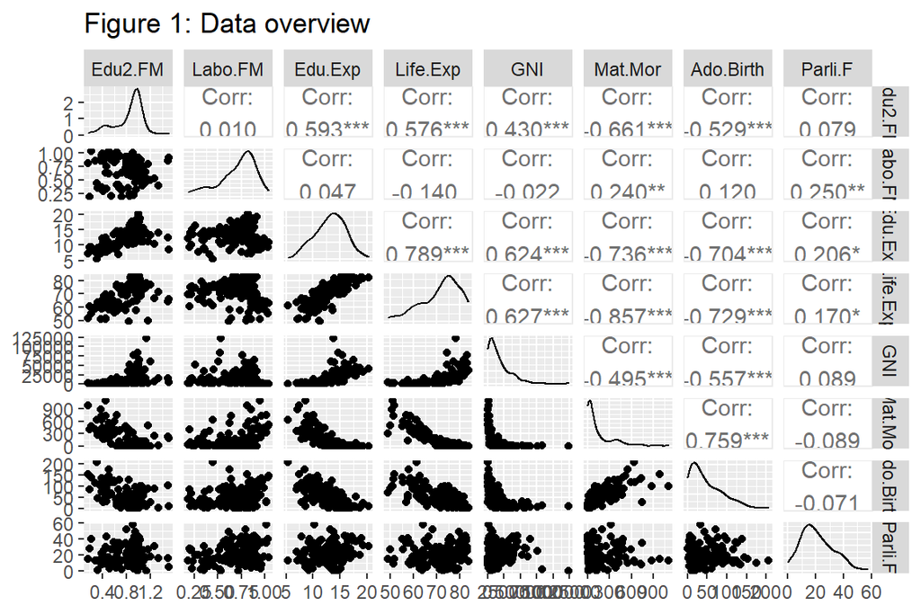

```r
library(dplyr)
library(ggplot2)
library(GGally)
library(corrplot)
ggpairs(human, title = "Figure 1: Data overview")
```

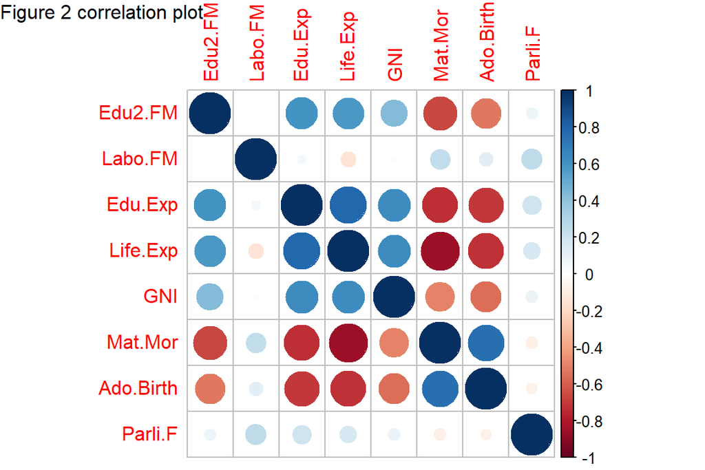

```r
#Computing the correlation matrix and visualizing it with corrplot
cor(human) %>% corrplot

mtext("Figure 2 correlation plot", side = 3, line = -1, adj =0, outer = TRUE)
```

As we can see we have a data set consisting of 155 observation for each of 8 varibles:

- Edu2.FM = Ratio of Female and Male populations with secondary education in each country
- Labo.FM = Ratio of labour force participation of females and males in each country
- Edu.Exp = Expected Years of Education
- Life.Exp = Life Expectancy at Birth
- GNI = Gross National Income (GNI) per Capita
- Mat.Mor “MMR” = Maternal Mortality Ratio
- Ado.Birth “ABR” = Adolescent Birth Rate
- Parli.F “PRP” = Percent Representation in Parliament

From figure 1, we can see that life expectancy is rather high in the majority of the observations and that adolescent birth rate, gross national income (GNI) per capita and maternal mortality ratio in general are rather low in most of the countries.

**Principal component analysis**

*With non-standardized data*

```r
#perform principal component analysis (with the SVD method)
pca_human <- prcomp(human)

#Creating a summary of pca_human
s <- summary(pca_human)
s
```

```
## Importance of components:
##                              PC1      PC2   PC3   PC4   PC5   PC6    PC7    PC8
## Standard deviation     1.854e+04 185.5219 25.19 11.45 3.766 1.566 0.1912 0.1591
## Proportion of Variance 9.999e-01   0.0001  0.00  0.00 0.000 0.000 0.0000 0.0000
## Cumulative Proportion  9.999e-01   1.0000  1.00  1.00 1.000 1.000 1.0000 1.0000
```

```r
pca_pr <- round(100*s$importance[2, ], digits = 1)

#The percentages of variance
pca_pr
```

```
## PC1 PC2 PC3 PC4 PC5 PC6 PC7 PC8
## 100   0   0   0   0   0   0   0
```

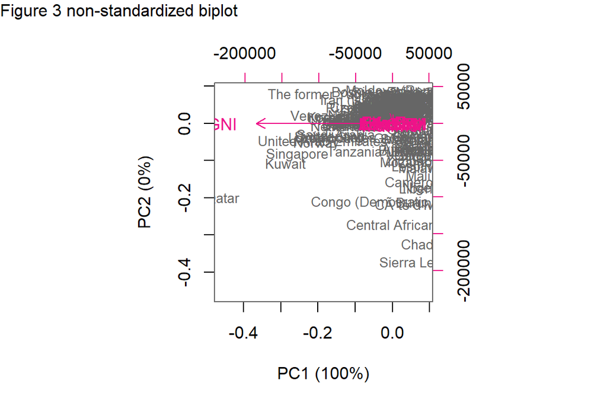

```r
#Creating object pc_lab (by the first two principal components) to be used as axis labels
pc_lab <- paste0(names(pca_pr), " (", pca_pr, "%)")

#Drawing a biplot
biplot(pca_human, cex = c(0.8, 1), col = c("grey40", "deeppink2"), xlab = pc_lab[1], ylab = pc_lab[2])
mtext("Figure 3 non-standardized biplot", side = 3, line = -1, adj =0, outer = TRUE)
```

*With standardized data*

```r
#Standardizing the variables
human_s <- scale(human)

#Performing PCA with the SVD method
pca_human_s <- prcomp(human_s)

#Creating a summary of pca_human
s_s <- summary(pca_human_s)
s_s
```

```
## Importance of components:
##                           PC1    PC2     PC3     PC4     PC5     PC6     PC7
## Standard deviation     2.0708 1.1397 0.87505 0.77886 0.66196 0.53631 0.45900
## Proportion of Variance 0.5361 0.1624 0.09571 0.07583 0.05477 0.03595 0.02634
## Cumulative Proportion  0.5361 0.6984 0.79413 0.86996 0.92473 0.96069 0.98702
##                            PC8
## Standard deviation     0.32224
## Proportion of Variance 0.01298
## Cumulative Proportion  1.00000
```

```r
pca_pr_s <- round(100*s_s$importance[2, ], digits = 1)

#The percentages of variance
pca_pr_s
```

```
##  PC1  PC2  PC3  PC4  PC5  PC6  PC7  PC8
## 53.6 16.2  9.6  7.6  5.5  3.6  2.6  1.3
```

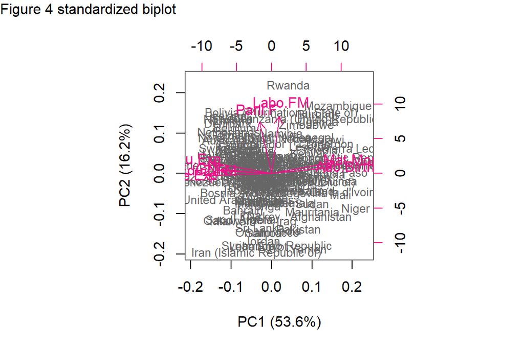

```r
#Creating object pc_lab (by the first two principal components) to be used as axis labels
pc_lab_s <- paste0(names(pca_pr_s), " (", pca_pr_s, "%)")

#Drawing a biplot
biplot(pca_human_s, cex = c(0.8, 1), col = c("grey40", "deeppink2"), xlab = pc_lab_s[1], ylab = pc_lab_s[2])
mtext("Figure 4 standardized biplot", side = 3, line = -1, adj =0, outer = TRUE)
```

**Comparison of the standardized and non-standardized principal component analysis**

As we can see the standardization is necessary for us to be able to make any seance of the data. In the case of not standardized, all variance is captured in PC1 and gross national income per capita (GNI) is overpowering all other variables, resulting in a oddly scaled graph that is impossible to interpret in any other way than that GNI is the varibel having the largest impact.

After we have performed the standardization, we can see that variance in captured for all of the 8 variables.

Good to remember when interpreting the finding in the principal component analysis graphs, the arrows are drawn to visualize the connections between the original features and the PC’s.

- The angle between arrows = correlation between the features (close to 0 degree angle = high positive correlation/ close to 180 degree = high negative correlation )
- The angle between an arrow an observation = correlation between the two. (small angle = high positive correlation)

With that background we can find that there is a correlation between GNI (Gross National Income (GNI) per Capita) and EDU2.FM(Ratio of Female and Male populations with secondary education in each country).

At the same time we can see that there is no clear correlation between any of the factors and Parli.F “PRP” (Percent representation in parliament).

**Multiple correspondence analysis**

For multiple correspondence analysis, we will use the ‘tea’ data set from the package ‘Factominer’. The structure of the data is explored and visualized below.

```r
library(FactoMineR)
library(dplyr)
library(ggplot2)
library(tidyr)

#Loading the data
data("tea")

#structure of the data set
str(tea)
```

```
## 'data.frame':    300 obs. of  36 variables:
##  $ breakfast       : Factor w/ 2 levels "breakfast","Not.breakfast": 1 1 2 2 1 2 1 2 1 1 ...
##  $ tea.time        : Factor w/ 2 levels "Not.tea time",..: 1 1 2 1 1 1 2 2 2 1 ...
##  $ evening         : Factor w/ 2 levels "evening","Not.evening": 2 2 1 2 1 2 2 1 2 1 ...
##  $ lunch           : Factor w/ 2 levels "lunch","Not.lunch": 2 2 2 2 2 2 2 2 2 2 ...
##  $ dinner          : Factor w/ 2 levels "dinner","Not.dinner": 2 2 1 1 2 1 2 2 2 2 ...
##  $ always          : Factor w/ 2 levels "always","Not.always": 2 2 2 2 1 2 2 2 2 2 ...
##  $ home            : Factor w/ 2 levels "home","Not.home": 1 1 1 1 1 1 1 1 1 1 ...
##  $ work            : Factor w/ 2 levels "Not.work","work": 1 1 2 1 1 1 1 1 1 1 ...
##  $ tearoom         : Factor w/ 2 levels "Not.tearoom",..: 1 1 1 1 1 1 1 1 1 2 ...
##  $ friends         : Factor w/ 2 levels "friends","Not.friends": 2 2 1 2 2 2 1 2 2 2 ...
##  $ resto           : Factor w/ 2 levels "Not.resto","resto": 1 1 2 1 1 1 1 1 1 1 ...
##  $ pub             : Factor w/ 2 levels "Not.pub","pub": 1 1 1 1 1 1 1 1 1 1 ...
##  $ Tea             : Factor w/ 3 levels "black","Earl Grey",..: 1 1 2 2 2 2 2 1 2 1 ...
##  $ How             : Factor w/ 4 levels "alone","lemon",..: 1 3 1 1 1 1 1 3 3 1 ...
```

[output cut: 22 more lines]

**In this data set there is 300 observations for 36 variables. As it’s hard to compare 36 variables at the same time, for further investigation we have selected six variables: how, How, lunch, sugar, Tea and where.**

```r
#column names to keep in the dataset
keep_columns <- c("Tea", "How", "how", "sugar", "where", "lunch")

#select the 'keep_columns' to create a new dataset
tea_time <- dplyr::select(tea, one_of(keep_columns))

#look at the summaries and structure of the data
summary(tea_time)
```

```
##         Tea         How                      how           sugar
##  black    : 74   alone:195   tea bag           :170   No.sugar:155
##  Earl Grey:193   lemon: 33   tea bag+unpackaged: 94   sugar   :145
##  green    : 33   milk : 63   unpackaged        : 36
##                  other:  9
##                   where           lunch
##  chain store         :192   lunch    : 44
##  chain store+tea shop: 78   Not.lunch:256
##  tea shop            : 30
##
```

```r
str(tea_time)
```

```
## 'data.frame':    300 obs. of  6 variables:
##  $ Tea  : Factor w/ 3 levels "black","Earl Grey",..: 1 1 2 2 2 2 2 1 2 1 ...
##  $ How  : Factor w/ 4 levels "alone","lemon",..: 1 3 1 1 1 1 1 3 3 1 ...
##  $ how  : Factor w/ 3 levels "tea bag","tea bag+unpackaged",..: 1 1 1 1 1 1 1 1 2 2 ...
##  $ sugar: Factor w/ 2 levels "No.sugar","sugar": 2 1 1 2 1 1 1 1 1 1 ...
##  $ where: Factor w/ 3 levels "chain store",..: 1 1 1 1 1 1 1 1 2 2 ...
##  $ lunch: Factor w/ 2 levels "lunch","Not.lunch": 2 2 2 2 2 2 2 2 2 2 ...
```

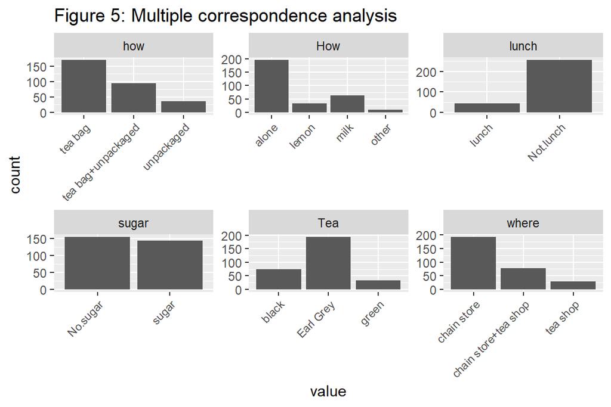

```r
#visualize the dataset
gather(tea_time) %>% ggplot(aes(value)) + facet_wrap("key", scales = "free") + geom_bar() + theme(axis.text.x = element_text(angle = 45, hjust = 1, size = 8)) + ggtitle("Figure 5: Multiple correspondence analysis")
```

As we can find from the panels in figure 5 the most common way to consume tea by drinking Earl gray tea from a tea bag whiteout any other liquids (as milk) added. It is almost as common to drinking with sugar added as drinking it neutral. While a few individuals consume there tea during lunch it is much more common to drink tea at another time point. Not surprisingly, considering that the most common tea is Earl gray from a tea bag, most individuals bought their tea in a chain store. It is likely looking at the amount of individual that drink black or green tea and the amount of people that buy there tea in a tea shop (including the group buying at both tea shop and chain store) that Earl gray is bought at a chain stores while the others is bought in tea shops. We can also see a very clear similarity in the amount of people that drink packaged tea and the amount people that buy tea in tea shops and it might be that most individuals buying loose tea buy it from tea shops.

**Another way to investigate the data is to crate the multiple correspondence analysis and create a biplot**

```r
#multiple correspondence analysis
mca <- MCA(tea_time, graph = FALSE)

#summary of the model
summary(mca)
```

```
##
## Call:
## MCA(X = tea_time, graph = FALSE)
##
##
## Eigenvalues
##                        Dim.1   Dim.2   Dim.3   Dim.4   Dim.5   Dim.6   Dim.7
## Variance               0.279   0.261   0.219   0.189   0.177   0.156   0.144
## % of var.             15.238  14.232  11.964  10.333   9.667   8.519   7.841
## Cumulative % of var.  15.238  29.471  41.435  51.768  61.434  69.953  77.794
##                        Dim.8   Dim.9  Dim.10  Dim.11
## Variance               0.141   0.117   0.087   0.062
## % of var.              7.705   6.392   4.724   3.385
## Cumulative % of var.  85.500  91.891  96.615 100.000
##
## Individuals (the 10 first)
##                       Dim.1    ctr   cos2    Dim.2    ctr   cos2    Dim.3
## 1                  | -0.298  0.106  0.086 | -0.328  0.137  0.105 | -0.327
## 2                  | -0.237  0.067  0.036 | -0.136  0.024  0.012 | -0.695
## 3                  | -0.369  0.162  0.231 | -0.300  0.115  0.153 | -0.202
## 4                  | -0.530  0.335  0.460 | -0.318  0.129  0.166 |  0.211
## 5                  | -0.369  0.162  0.231 | -0.300  0.115  0.153 | -0.202
## 6                  | -0.369  0.162  0.231 | -0.300  0.115  0.153 | -0.202
## 7                  | -0.369  0.162  0.231 | -0.300  0.115  0.153 | -0.202
## 8                  | -0.237  0.067  0.036 | -0.136  0.024  0.012 | -0.695
## 9                  |  0.143  0.024  0.012 |  0.871  0.969  0.435 | -0.067
## 10                 |  0.476  0.271  0.140 |  0.687  0.604  0.291 | -0.650
##                       ctr   cos2
## 1                   0.163  0.104 |
## 2                   0.735  0.314 |
## 3                   0.062  0.069 |
## 4                   0.068  0.073 |
## 5                   0.062  0.069 |
## 6                   0.062  0.069 |
## 7                   0.062  0.069 |
## 8                   0.735  0.314 |
## 9                   0.007  0.003 |
## 10                  0.643  0.261 |
##
## Categories (the 10 first)
```

[output cut: 16 more lines]

```
## lemon                3.226 |   1.329  14.771   0.218   8.081 |
## milk                 2.422 |   0.013   0.003   0.000   0.116 |
## other                5.534 |  -2.524  14.526   0.197  -7.676 |
## tea bag             -6.941 |  -0.065   0.183   0.006  -1.287 |
## tea bag+unpackaged  11.956 |   0.019   0.009   0.000   0.226 |
## unpackaged          -6.482 |   0.257   0.602   0.009   1.640 |
##
## Categorical variables (eta2)
##                      Dim.1 Dim.2 Dim.3
## Tea                | 0.126 0.108 0.410 |
## How                | 0.076 0.190 0.394 |
## how                | 0.708 0.522 0.010 |
## sugar              | 0.065 0.001 0.336 |
## where              | 0.702 0.681 0.055 |
## lunch              | 0.000 0.064 0.111 |
```

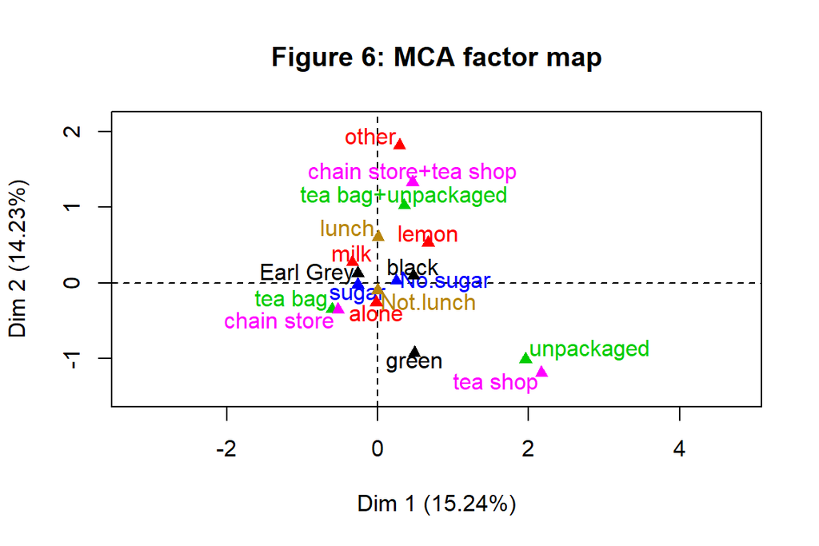

```r
#visualize MCA
plot(mca, invisible=c("ind"), habillage = "quali", graph.type = "classic", title = "Figure 6: MCA factor map")
```

Interestingly, we can from the plot visualized in figure 6 see that our assumption that tea bags are most commonly bought in chain stores, and Earl gray is much closer related to chain store and tea bag is correct. We can also we that unpackaged tea and tea shop is closely related and far from the previously mentioned variables. However no clear connection between green/black tea and shopping area could be found.

In conclusion multiple correspondence analysis and biplots is a nice way to investigate the relationship between multiple variables at the same time.

# Analysis of longitudinal data

```r
date()
```

```
## [1] "Sun Dec 12 20:47:18 2021"
```

This weeks analysis focus two different data sets with repeated measurements data.The first data set (RATS) focus on how three different diets influence the weight development in rats over time, where the weight was checked for 9 consecutive weeks, with dual measurements during week 6. The second data set (BPRS = brief psychiatric rating scale) investigate how a new treatment approach for depression (“Beat the Blues” (BtB)) stands against the current treatment setup (“Treatment as Usual” (TAU)).

The data set used in this chapter have been transformed from the original wide form to longitudinal form, meaning that we also can investigate this data with a connection between the data points in each of the series of measurements for each of our objects.

## RATS data analysis

```r
RATSL = read.table(file="RATSL.txt", sep=",", header=TRUE)

#Factor ID & Group of RATS
RATSL$ID <- factor(RATSL$ID)
RATSL$Group <- factor(RATSL$Group)

#Structure of the data
str(RATSL)
```

```
## 'data.frame':    176 obs. of  5 variables:
##  $ ID    : Factor w/ 16 levels "1","2","3","4",..: 1 2 3 4 5 6 7 8 9 10 ...
##  $ Group : Factor w/ 3 levels "1","2","3": 1 1 1 1 1 1 1 1 2 2 ...
##  $ times : chr  "WD1" "WD1" "WD1" "WD1" ...
##  $ Weight: int  240 225 245 260 255 260 275 245 410 405 ...
##  $ Time  : int  1 1 1 1 1 1 1 1 1 1 ...
```

We can see from the first investigation of the data that we have in total 176 observations of 5 variables.The “ID” variable is the identification number of the specific rat and the “Group” variable represent the three different diets investigated. The variable ‘Times’ has been constructed out of ‘times’ and each number is connected to the order of the weight measurement.The ‘Weight’ variable is the weight of the rat in grams.

*To get a first insight into how the data display, a graph is created with the Weight at the Y-axis and time on the X-axis.*

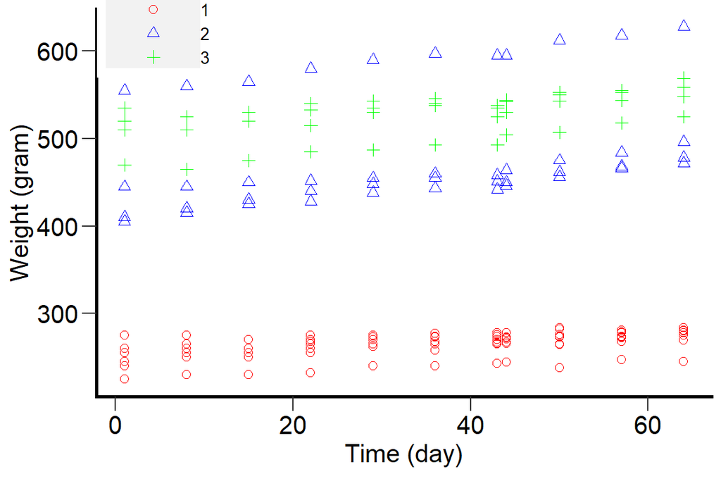

```r
library(ggplot2)
library(svglite)
require(mgcv)
ggplot(RATSL, aes(x=Time, y=Weight, shape=Group, color=Group)) +
  geom_point(size=2.2) +
    scale_shape_manual(values=c(1,2,3)) +
    scale_color_manual(values=c("red","blue","green")) +
  theme(panel.background=element_rect(fill=NA), axis.line=element_line(size=1,colour="Black", lineend="square"),
        legend.text=element_text(size=10), legend.title=element_text(size=0),
        axis.text=element_text(size=15,color="black"), axis.title=element_text(size=15), axis.ticks.length=unit(.3,"cm"),
        legend.position= 'none',legend.key.height = unit(0.5,"cm"),legend.key.width = unit(2,"cm")) +
   theme(panel.background=element_rect(fill=NA), axis.line=element_line(size=1,colour="Black", lineend="square"),
  legend.text=element_text(size=10), legend.title=element_text(size=0),
  axis.text=element_text(size=15,color="black"), axis.title=element_text(size=15), axis.ticks.length=unit(.3,"cm"),
  legend.position=c(0.10,0.94),legend.key.height = unit(0.5,"cm"),legend.key.width = unit(2,"cm")) +
  labs(x=expression("Time (day)")) + labs(y="Weight (gram)")
```

*To make it a bit more clear which animal in the group each group will get an own shape*

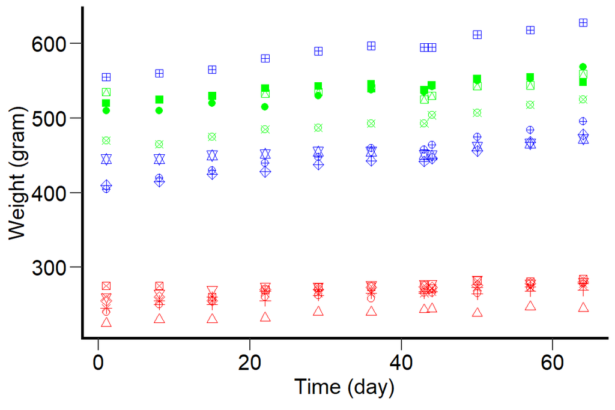

```r
library(ggplot2)
library(svglite)
require(mgcv)

ggplot(RATSL, aes(x=Time, y=Weight, shape=ID, color=Group)) +
  geom_point(size=2.2) +
    scale_shape_manual(values=c(1,2,3,4,5,6,7,8,9,10,11,12,13,14,15,16)) +
    scale_color_manual(values=c("red","blue","green")) +
  theme(panel.background=element_rect(fill=NA), axis.line=element_line(size=1,colour="Black", lineend="square"),
        legend.text=element_text(size=10), legend.title=element_text(size=0),
        axis.text=element_text(size=15,color="black"), axis.title=element_text(size=15), axis.ticks.length=unit(.3,"cm"),
        legend.position= 'none',legend.key.height = unit(0.5,"cm"),legend.key.width = unit(2,"cm")) +
  labs(x=expression("Time (day)")) + labs(y="Weight (gram)")
```

*To follow the instruction to implement the analyses of Chapter 8 of MABS analysis from the rats data an addition graph is generated where the groups is plotted in separated side by side windows*

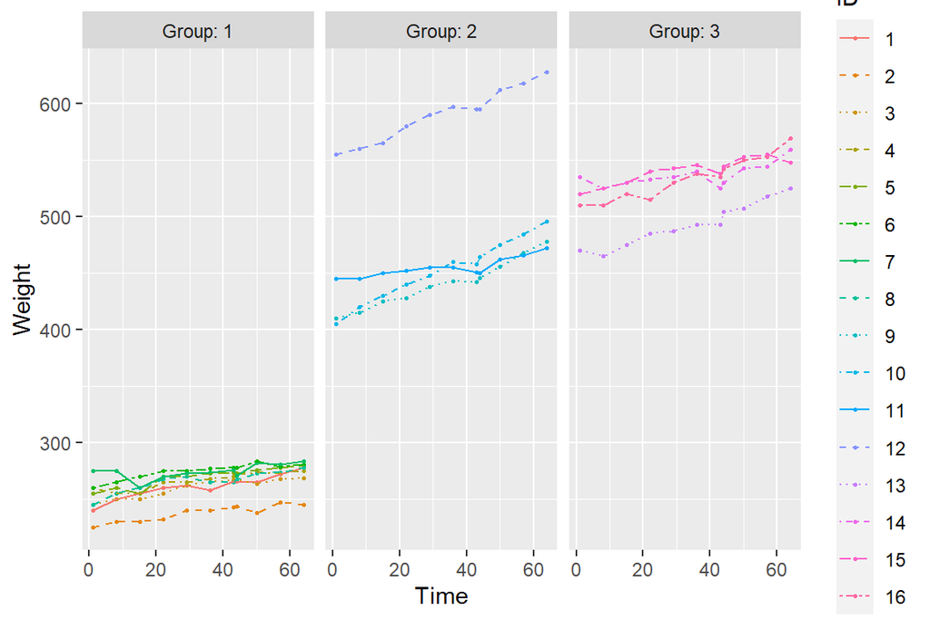

```r
#Drawing a new plot using ggplot
ggplot(RATSL, aes(x = Time, y = Weight, linetype = ID, color = ID)) +
  geom_point(size = 0.5) +
  geom_line(aes(group = ID)) +
  scale_linetype_manual(values = rep(1:10, times=4)) +
  facet_grid(. ~ Group, labeller = label_both) +
  scale_y_continuous(limits = c(min(RATSL$Weight), max(RATSL$Weight)))
```

From the second and third graph created we can see that for each of the groups there exist one animal that starts with an either higher or lower weight than the rest of the group e.g., rat 2, 12 and 13. One way to overcome such issue and the within group differences (except ordering the animals with the same weight) would be to convert the data to % increase from baseline. This standardization is done by dividing the weight at each time point with the weight at the first time point and multiplying with 100. This approach of course has it’s limitation in that we assume that the weigh change is only dependent on the diet and that the difference in weight from the beginning is random and not related to age or status in the group. Lets at the same time also try to standardize the data as described in chapter 8 of MABS to see how this will affect the display. In the second example we perform the standardization by subtracting the relevant occasion mean from the original observation and then dividing by the corresponding visit standard deviation.

```r
library(dplyr)

#Adding the variable Change from baseline CHG
RATSLst <- RATSL %>%
  arrange(ID) %>%
  group_by(ID) %>%
  mutate(CHG = ((Weight/ Weight[1L])*100)) %>%
  ungroup()

glimpse(RATSLst)
```

```
## Rows: 176
## Columns: 6
## $ ID     <fct> 1, 1, 1, 1, 1, 1, 1, 1, 1, 1, 1, 2, 2, 2, 2, 2, 2, 2, 2, 2, 2, ~
## $ Group  <fct> 1, 1, 1, 1, 1, 1, 1, 1, 1, 1, 1, 1, 1, 1, 1, 1, 1, 1, 1, 1, 1, ~
## $ times  <chr> "WD1", "WD8", "WD15", "WD22", "WD29", "WD36", "WD43", "WD44", "~
## $ Weight <int> 240, 250, 255, 260, 262, 258, 266, 266, 265, 272, 278, 225, 230~
## $ Time   <int> 1, 8, 15, 22, 29, 36, 43, 44, 50, 57, 64, 1, 8, 15, 22, 29, 36,~
## $ CHG    <dbl> 100.0000, 104.1667, 106.2500, 108.3333, 109.1667, 107.5000, 110~
```

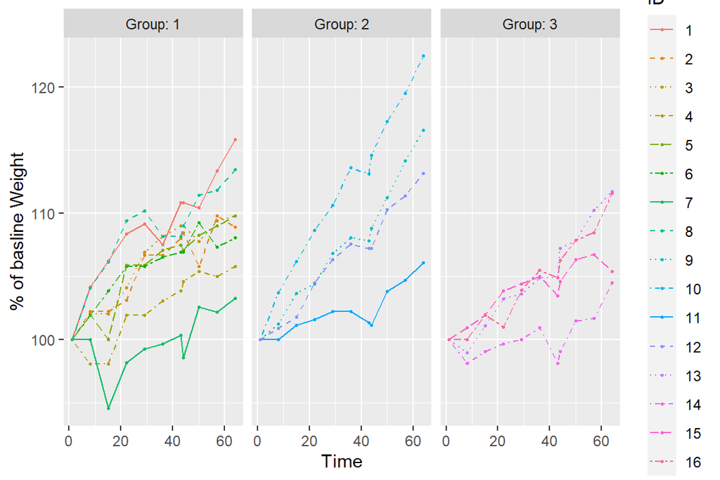

```r
#Plotting with % change from basline
ggplot(RATSLst, aes(x = Time, y = CHG, linetype = ID, color = ID)) +
  geom_point(size = 0.5) +
  geom_line() +
  scale_linetype_manual(values = rep(1:10, times=4)) +
  facet_grid(. ~ Group, labeller = label_both) +
  scale_y_continuous(name = "% of basline Weight")
```

```r
#Standardising the variable Weight
RATSL <- RATSL %>%
  group_by(Time) %>%
  mutate(stdweight = (Weight - mean(Weight))/sd(Weight) ) %>%
  ungroup()

glimpse(RATSL)
```

```
## Rows: 176
## Columns: 6
## $ ID        <fct> 1, 2, 3, 4, 5, 6, 7, 8, 9, 10, 11, 12, 13, 14, 15, 16, 1, 2,~
## $ Group     <fct> 1, 1, 1, 1, 1, 1, 1, 1, 2, 2, 2, 2, 3, 3, 3, 3, 1, 1, 1, 1, ~
## $ times     <chr> "WD1", "WD1", "WD1", "WD1", "WD1", "WD1", "WD1", "WD1", "WD1~
## $ Weight    <int> 240, 225, 245, 260, 255, 260, 275, 245, 410, 405, 445, 555, ~
## $ Time      <int> 1, 1, 1, 1, 1, 1, 1, 1, 1, 1, 1, 1, 1, 1, 1, 1, 8, 8, 8, 8, ~
## $ stdweight <dbl> -1.0011429, -1.1203857, -0.9613953, -0.8421525, -0.8819001, ~
```

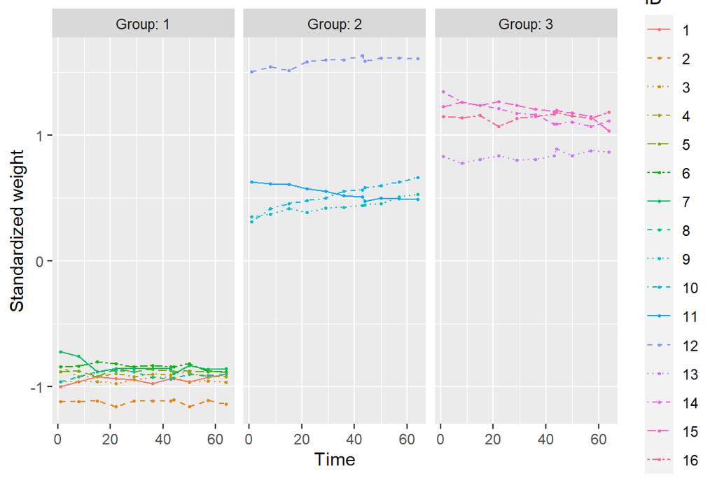

```r
#Plotting the standardized weight according to MASB
ggplot(RATSL, aes(x = Time, y = stdweight, linetype = ID, color = ID)) +
  geom_point(size = 0.5) +
  geom_line() +
  scale_linetype_manual(values = rep(1:10, times=4)) +
  facet_grid(. ~ Group, labeller = label_both) +
  scale_y_continuous(name = "Standardized weight")
```

The % change from baseline graph give us a completely different insight to the data than what we saw before accounting for the huge difference in weight at the start of the study. We can for example see that even though the absolute weight is lowest for the first group at all time points the relative change in weight don’t seem to be too different from the other two groups, rather it could be the mean group.

*To continue lets work with both data sets and investigates the within group variation, by plotting the mean and standard error of mean.*

```r
library(dplyr)
#Number of weighting times
n <- RATSLst$Time %>% unique() %>% length()
n2 <- RATSL$Time %>% unique() %>% length()

#Summary data with mean and standard error of Weight by Group and Time

RATSLstS <- RATSLst %>%
  group_by(Group, Time) %>%
  summarise(mean = mean(CHG), se = sd(CHG)/sqrt(n)) %>%
  ungroup()
```

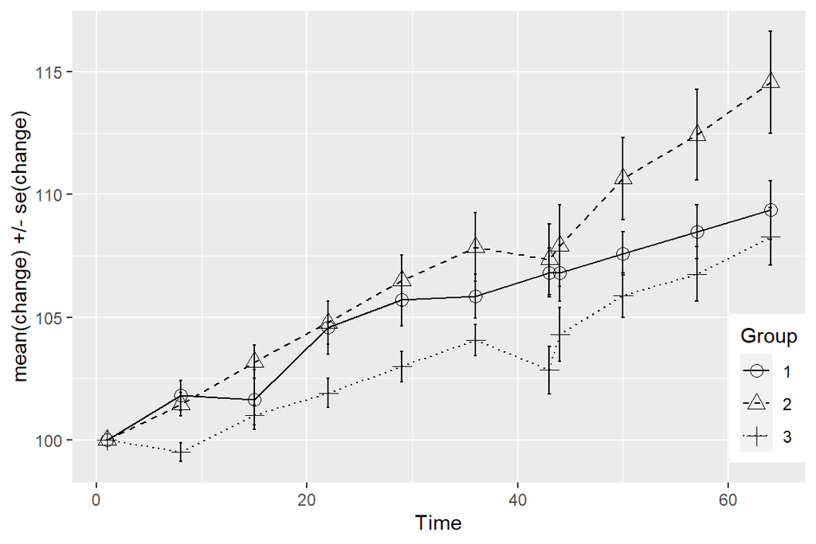

```r
#Plotting the mean profiles
ggplot(RATSLstS, aes(x = Time, y = mean, linetype = Group, shape = Group)) +
  geom_line() +
  scale_linetype_manual(values = c(1,2,3)) +
  geom_point(size=3) +
  scale_shape_manual(values = c(1,2,3)) +
  geom_errorbar(aes(ymin = mean - se, ymax = mean + se, linetype="1"), width=0.3) +
  theme(legend.position = c(0.95,0.2)) +
  scale_y_continuous(name = "mean(change) +/- se(change)")
```

```r
RATSS <- RATSL %>%
  group_by(Group, Time) %>%
  summarise( mean = mean(Weight), se = sd(Weight)/sqrt(n2)) %>%
  ungroup()
```

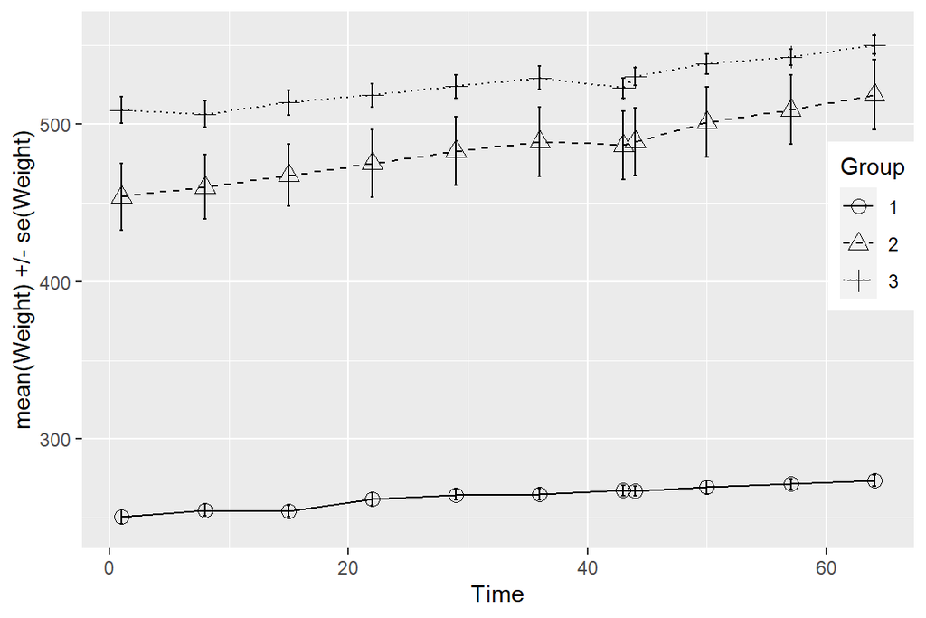

```r
#Plotting the mean profiles
ggplot(RATSS, aes(x = Time, y = mean, linetype = Group, shape = Group)) +
  geom_line() +
  scale_linetype_manual(values = c(1,2,3)) +
  geom_point(size=3) +
  scale_shape_manual(values = c(1,2,3)) +
  geom_errorbar(aes(ymin = mean - se, ymax = mean + se, linetype="1"), width=0.3) +
  theme(legend.position = c(0.95,0.6)) +
  scale_y_continuous(name = "mean(Weight) +/- se(Weight)")
```

Interestingly we can see that the interpretation of this data set will be completely different if we assess the % change from baseline or if we are just accepting that the initial weight also is associated to the diet and we just got to analyze a 9 week part of the data collected late in the study. With the limited knowledge I have been able to access without being able to read the original experimental setup, I would say that the % change is more relevant.

*Lets continue with creating boxplots of the mean to allow for later performing some statistical tests*

```r
library(dplyr)
#Creating a summary data by Group and ID
RATSSbp <- RATSL %>%
  group_by(Group, ID) %>%
  summarise(mean=mean(Weight)) %>%
  ungroup()
```

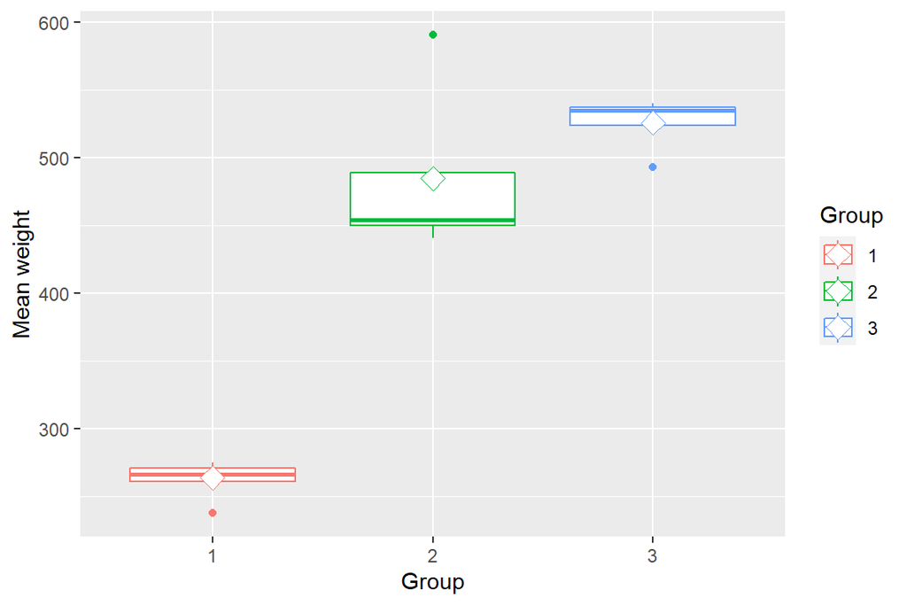

```r
#Drawing a boxplot of the mean versus group
ggplot(RATSSbp, aes(x = Group, y = mean, col=Group)) +
  geom_boxplot() +
  stat_summary(fun = "mean", geom = "point", shape=23, size=4, fill = "white") +
  scale_y_continuous(name = "Mean weight")
```

```r
#Creating a summary data by Group and ID using the % chang data
RATSLstbp <- RATSLst %>%
  group_by(Group, ID) %>%
  summarise(mean=mean(CHG)) %>%
  ungroup()
```

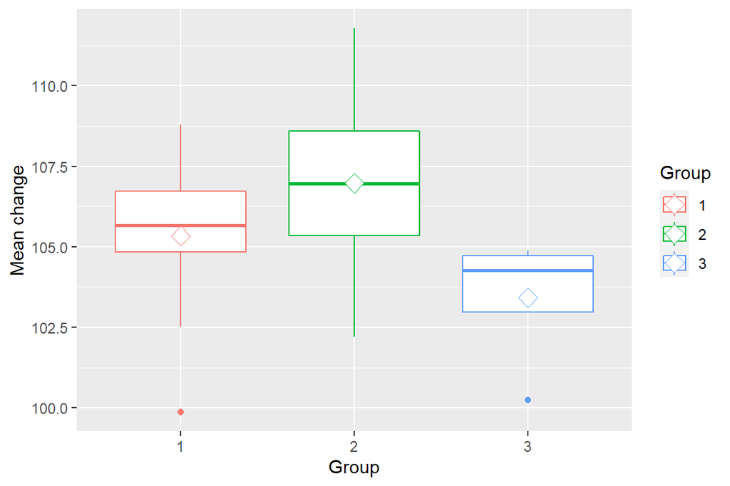

```r
#Drawing a boxplot of the mean versus group
ggplot(RATSLstbp, aes(x = Group, y = mean, col=Group)) +
  geom_boxplot() +
  stat_summary(fun = "mean", geom = "point", shape=23, size=4, fill = "white") +
  scale_y_continuous(name = "Mean change")
```

We can see that we have out-liers in both analysis, but the influence of the out-liers on the mean is larger in the mean weight than in the mean change.

*Finally we will perform some statistical comparison of the diets in the data sets.*

```r
library(rstatix)
library(ggpubr)
#Summary statistics of the data
RATSSbp %>%
  group_by(Group) %>%
  get_summary_stats(mean, type = "mean_sd")
```

```
## # A tibble: 3 x 5
##   Group variable     n  mean    sd
##   <fct> <chr>    <dbl> <dbl> <dbl>
## 1 1     mean         8  264.  11.9
## 2 2     mean         4  485.  70.8
## 3 3     mean         4  526.  22.1
```

```r
#Completing a pairwise t-tests
pwt <- RATSSbp %>%
  pairwise_t_test(mean ~ Group, p.adjust.method = "bonferroni")

pwt
```

```
## # A tibble: 3 x 9
##   .y.   group1 group2    n1    n2            p p.signif       p.adj p.adj.signif
## * <chr> <chr>  <chr>  <int> <int>        <dbl> <chr>          <dbl> <chr>
## 1 mean  1      2          8     4 0.000000216  ****         6.48e-7 ****
## 2 mean  1      3          8     4 0.0000000291 ****         8.72e-8 ****
## 3 mean  2      3          4     4 0.137        ns           4.11e-1 ns
```

```r
#Summary statistics of the data
RATSLstbp %>%
  group_by(Group) %>%
  get_summary_stats(mean, type = "mean_sd")
```

```
## # A tibble: 3 x 5
##   Group variable     n  mean    sd
##   <fct> <chr>    <dbl> <dbl> <dbl>
## 1 1     mean         8  105.  2.92
## 2 2     mean         4  107.  3.94
## 3 3     mean         4  103.  2.16
```

```r
#Completing a pairwise t-tests
pwtst <- RATSLstbp %>%
  pairwise_t_test(mean ~ Group, p.adjust.method = "bonferroni")

pwtst
```

```
## # A tibble: 3 x 9
##   .y.   group1 group2    n1    n2     p p.signif p.adj p.adj.signif
## * <chr> <chr>  <chr>  <int> <int> <dbl> <chr>    <dbl> <chr>
## 1 mean  1      2          8     4 0.395 ns       1     ns
## 2 mean  1      3          8     4 0.322 ns       0.967 ns
## 3 mean  2      3          4     4 0.122 ns       0.367 ns
```

**In conclusion, as mentioned multiple times during this part of the exercise, the background information of the data set is limited and it’s tempting to just go with the data and get a nice significant affect of the diet. However, since we want to scientifically evaluate the affect of the diet from day 1 to day 64, we need to normalize the data between groups in a way that make the effect compatible and independent of the initial value. My way to do this is to recalculate all data points to % from baseline. From those graphs and statistical comparisons it is safe to say that there is no affect of the diet on the weight gain, rather the difference between groups is a result of the skewed baseline values.**

## BPRS data analysis

```r
BPRSL = read.table(file="BPRSL.txt", sep=",", header=TRUE)

#Factor treatment & subject of BPRSL
BPRSL$treatment <- factor(BPRSL$treatment)
BPRSL$subject <- factor(BPRSL$subject)

#Let us see the dimensions and structure of the dataset
str(BPRSL)
```

```
## 'data.frame':    360 obs. of  5 variables:
##  $ treatment: Factor w/ 2 levels "1","2": 1 1 1 1 1 1 1 1 1 1 ...
##  $ subject  : Factor w/ 20 levels "1","2","3","4",..: 1 2 3 4 5 6 7 8 9 10 ...
##  $ weeks    : chr  "week0" "week0" "week0" "week0" ...
##  $ bprs     : int  42 58 54 55 72 48 71 30 41 57 ...
##  $ week     : int  0 0 0 0 0 0 0 0 0 0 ...
```

We can see from the first investigation of the data that we have in total 360 observations of 5 variables.The “treatment” variable is derived from the two treatment approaches that has been used. The “subjects” variable represent the individual patients. The variable “Week” has been constructed out of “weeks” and each number is connected to the order of the bprs scoring time points. The variable “bprs” represent the brief psychiatric rating scale score of the patients.

**To first investigate the data we plot the data set with week on the x-axis and score on the y-axis**

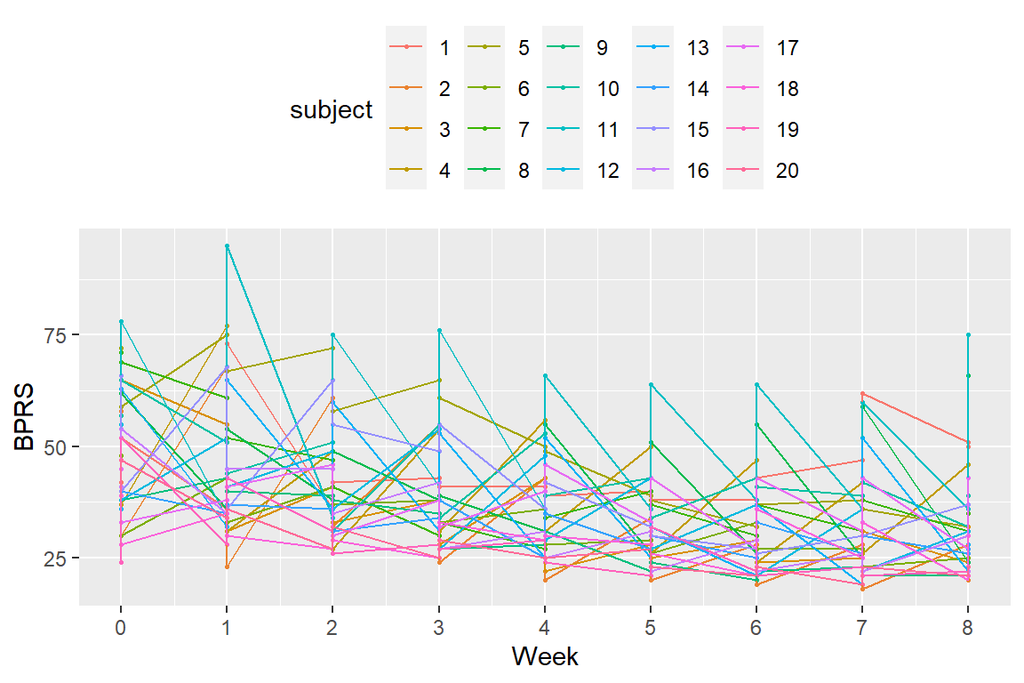

```r
#Plotting the BPRS data
ggplot(BPRSL, aes(x = week, y = bprs, col = subject)) +
  geom_point(size = 0.5) +
  geom_line() + scale_x_continuous(name = "Week", breaks = seq(0, 8, 1)) + scale_y_continuous(name = "BPRS") + theme(legend.position = "top")
```

**To make the plot a little more easy to comprehend the data is plotted again, but with the treatments groups devided**

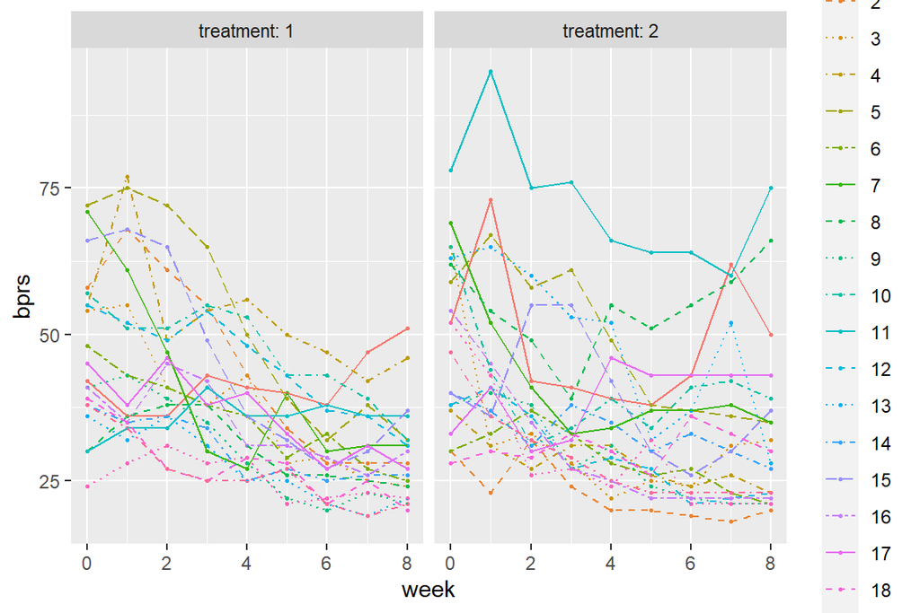

```r
#Plotting the BPRS data once more
ggplot(BPRSL, aes(x = week, y = bprs, linetype = subject, col = subject)) +
  geom_point(size = 0.5) +
  geom_line() +
  scale_linetype_manual(values = rep(1:10, times=4)) +
  facet_grid(. ~ treatment, labeller = label_both) +
  scale_y_continuous(limits = c(min(BPRSL$bprs), max(BPRSL$bprs)))
```

Since the initial bprs-scores don´t seem to differ between the treatment groups we can likely continue with the original data. Before creating linear mixed effects models for the repeated measures data, as described in MABS chapter 9, we will plot the data sets in the same graph with the mean and standard error of mean for each of the time points.

```r
library(dplyr)
#Number of subject
n3 <- BPRSL$subject %>% unique() %>% length()

#Summary data with mean and standard error of bprs by treatment and week
BPRSS <- BPRSL %>%
  group_by(treatment, week) %>%
  summarise(mean = mean(bprs), se = sd(bprs)/sqrt(n3)) %>%
  ungroup()
```

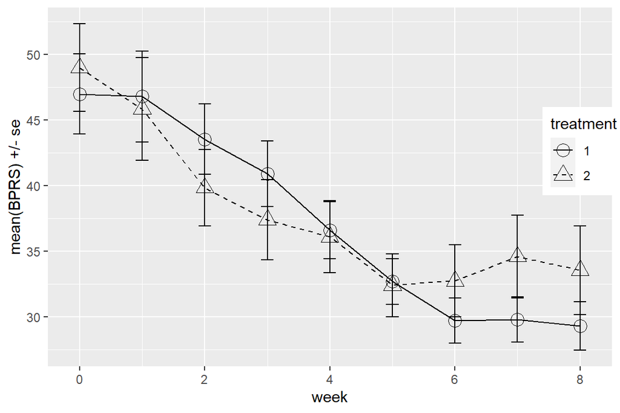

```r
#Plotting the mean profiles of subjects
ggplot(BPRSS, aes(x = week, y = mean, linetype = treatment, shape = treatment)) +
  geom_line(aes(group = treatment)) +
  scale_linetype_manual(values = c(1,2)) +
  geom_point(size=4) +
  scale_shape_manual(values = c(1,2)) +
  geom_errorbar(aes(ymin = mean - se, ymax = mean + se, linetype="1"), width=0.2) +
  theme(legend.position = c(0.95,0.6)) +
  scale_y_continuous(name = "mean(BPRS) +/- se")
```

From the plotted mean with standard error of mean we can see that there is an overlap of the treatment scoring between the treatment groups. What’s most interesting is however that wee can observe a potential difference in the pattern of the treatment efficiency. While the second treatment group have a larger effect during the first 4 weeks, treatment one is caching up and is passing in efficacy from week 6 where the second treatment also is starting to lose it’s effect slightly. To gain a better knowledge of the long term influence of the treatments for depression, it would be interesting to have also later time points to see if the effect of treatment one is continuing to be stable and whether treatment two is losing it’s effect more with the time.

**Linear mixed effects models for repeated measures data**

**We first fit a linear regression model ignoring the repeated measures structure of the data before taking the repetitive nature in account,just to be able to compere the models.** In the primary model BPRS will act as response variable, and week + treatment will be used as as explanatory variables.

```r
#Creating a regression model RATS_reg
BPRS_reg <- lm(bprs ~ week + treatment, data = BPRSL)

#Printing a summary of the model
summary(BPRS_reg)
```

```
##
## Call:
## lm(formula = bprs ~ week + treatment, data = BPRSL)
##
## Residuals:
##     Min      1Q  Median      3Q     Max
## -22.454  -8.965  -3.196   7.002  50.244
##
## Coefficients:
##             Estimate Std. Error t value Pr(>|t|)
## (Intercept)  46.4539     1.3670  33.982   <2e-16 ***
## week         -2.2704     0.2524  -8.995   <2e-16 ***
## treatment2    0.5722     1.3034   0.439    0.661
## ---
## Signif. codes:  0 '***' 0.001 '**' 0.01 '*' 0.05 '.' 0.1 ' ' 1
##
## Residual standard error: 12.37 on 357 degrees of freedom
## Multiple R-squared:  0.1851, Adjusted R-squared:  0.1806
## F-statistic: 40.55 on 2 and 357 DF,  p-value: < 2.2e-16
```

Without taking the repeated nature of the data in to account, we can see that there is a significant correlation between bprs score and the number of weeks that the treatment has been used. There is however no significant difference between the treatments.’

**We now fit a linear regression model allowed to take the repeated measures structure of the data into account**. This is done by using a random intercept model. The random component is assumed to be normally distributed and constant in time. Thereby, the linear fit for each subject is now allowed to differ in intercept from other subjects.

```r
library(lme4)
#Creating a random intercept model
BPRS_ref <- lmer(bprs ~ week + treatment + (1 | subject), data = BPRSL, REML = FALSE)

#Printing the summary of the model
summary(BPRS_ref)
```

```
## Linear mixed model fit by maximum likelihood  ['lmerMod']
## Formula: bprs ~ week + treatment + (1 | subject)
##    Data: BPRSL
##
##      AIC      BIC   logLik deviance df.resid
##   2748.7   2768.1  -1369.4   2738.7      355
##
## Scaled residuals:
##     Min      1Q  Median      3Q     Max
## -3.0481 -0.6749 -0.1361  0.4813  3.4855
##
## Random effects:
##  Groups   Name        Variance Std.Dev.
##  subject  (Intercept)  47.41    6.885
##  Residual             104.21   10.208
## Number of obs: 360, groups:  subject, 20
##
## Fixed effects:
##             Estimate Std. Error t value
## (Intercept)  46.4539     1.9090  24.334
## week         -2.2704     0.2084 -10.896
## treatment2    0.5722     1.0761   0.532
##
## Correlation of Fixed Effects:
##            (Intr) week
## week       -0.437
## treatment2 -0.282  0.000
```

We can from the output t-values confirm the significant difference in the time points of the scoring (week), while there is still no difference between the treatment groups. We can also see that taking the repeated nature of the data in to account result in a decrease in the standard error of the “week” variable.

**To see if we can improve our model further we will produce two additional models. First one that in addition to allowing the intercept to differ also allowing the slope of each of the individual plots to differ by fitting a random intercept and random slope model to the data. Secondly by also allowing for a group and time interaction**

```r
#Creating a random intercept and random slope model
BPRS_ref1 <- lmer(bprs ~ week + treatment + (week | subject), data = BPRSL, REML = FALSE)

#Printing a summary of the model
summary(BPRS_ref1)
```

```
## Linear mixed model fit by maximum likelihood  ['lmerMod']
## Formula: bprs ~ week + treatment + (week | subject)
##    Data: BPRSL
##
##      AIC      BIC   logLik deviance df.resid
##   2745.4   2772.6  -1365.7   2731.4      353
##
## Scaled residuals:
##     Min      1Q  Median      3Q     Max
## -2.8919 -0.6194 -0.0691  0.5531  3.7976
##
## Random effects:
##  Groups   Name        Variance Std.Dev. Corr
##  subject  (Intercept) 64.8222  8.0512
##           week         0.9609  0.9802   -0.51
##  Residual             97.4305  9.8707
## Number of obs: 360, groups:  subject, 20
##
## Fixed effects:
##             Estimate Std. Error t value
## (Intercept)  46.4539     2.1052  22.066
## week         -2.2704     0.2977  -7.626
## treatment2    0.5722     1.0405   0.550
##
## Correlation of Fixed Effects:
##            (Intr) week
## week       -0.582
## treatment2 -0.247  0.000
```

```r
#Creating a random intercept and random slope model with the interaction
BPRS_ref2 <- lmer(bprs ~ week * treatment + (week | subject), data = BPRSL, REML = FALSE)

#Printing a summary of the model
summary(BPRS_ref2)
```

```
## Linear mixed model fit by maximum likelihood  ['lmerMod']
## Formula: bprs ~ week * treatment + (week | subject)
##    Data: BPRSL
##
##      AIC      BIC   logLik deviance df.resid
##   2744.3   2775.4  -1364.1   2728.3      352
##
## Scaled residuals:
##     Min      1Q  Median      3Q     Max
## -3.0512 -0.6271 -0.0768  0.5288  3.9260
##
## Random effects:
##  Groups   Name        Variance Std.Dev. Corr
##  subject  (Intercept) 64.9964  8.0620
##           week         0.9687  0.9842   -0.51
##  Residual             96.4707  9.8220
## Number of obs: 360, groups:  subject, 20
##
## Fixed effects:
##                 Estimate Std. Error t value
## (Intercept)      47.8856     2.2521  21.262
## week             -2.6283     0.3589  -7.323
## treatment2       -2.2911     1.9090  -1.200
## week:treatment2   0.7158     0.4010   1.785
##
## Correlation of Fixed Effects:
##             (Intr) week   trtmn2
## week        -0.650
## treatment2  -0.424  0.469
## wek:trtmnt2  0.356 -0.559 -0.840
```

*We then want to compare how well the new models fit the data in comparison to the first one we did. First by performing an ANOVA test comparing the model where we allow for intercept and slop to be individual with the one where only intercept is individual.*

```r
#Performing an ANOVA test on the two models
anova(BPRS_ref1, BPRS_ref)
```

```
## Data: BPRSL
## Models:
## BPRS_ref: bprs ~ week + treatment + (1 | subject)
## BPRS_ref1: bprs ~ week + treatment + (week | subject)
##           npar    AIC    BIC  logLik deviance  Chisq Df Pr(>Chisq)
## BPRS_ref     5 2748.7 2768.1 -1369.4   2738.7
## BPRS_ref1    7 2745.4 2772.6 -1365.7   2731.4 7.2721  2    0.02636 *
## ---
## Signif. codes:  0 '***' 0.001 '**' 0.01 '*' 0.05 '.' 0.1 ' ' 1
```

Aa we can see in the output table the Chisq P- value, corresponding to the likely hood that the Chisq value would arise randomly, is rather small and is considered significant. This would suggest that the model allowing for both individual intercept and slop has a better fit to our data than the primary model.